## ggplot examples using Jeju travel data

```r
library(dplyr)
library(ggplot2)
```

분석주제 1. 시별 카드사용 건수

제주 시별로 카드사용 건수를 시각화.  
제주시가 서귀포시보다 더 많은 이용건수를 보인다.

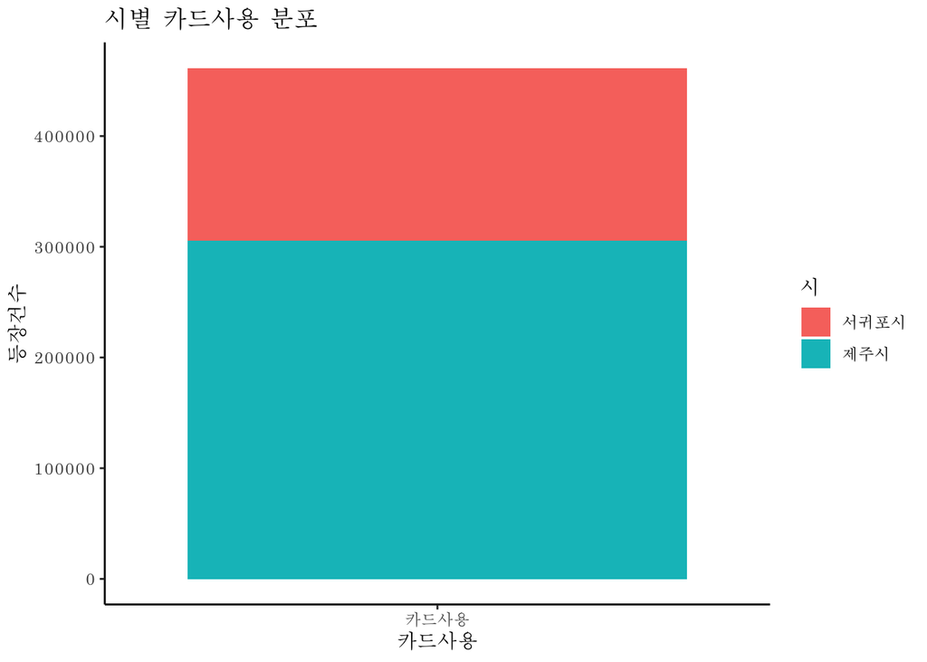

```r
ggplot(jj) +
  geom_bar(aes('카드사용', fill = CARD_CCG_NM)) +
  xlab('카드사용') + ylab('등장건수') + theme_classic(base_family = f.fam) +
  ggtitle('시별 카드사용 분포') + labs(fill = '시')
```

분석주제 2.1. 이용금액 vs. 업종 박스플랏

수치형 자료인 카드 사용금액의 로그변환 박스플랏. 사용금액의 단위가 크므로 로그변환을 취하였다. 사용금액의 중위수 순으로 정렬하였으며, 건강보조식품 소매업의 이용금액이 중위수 기준으로 가장 크며 그 산포도 작었다.

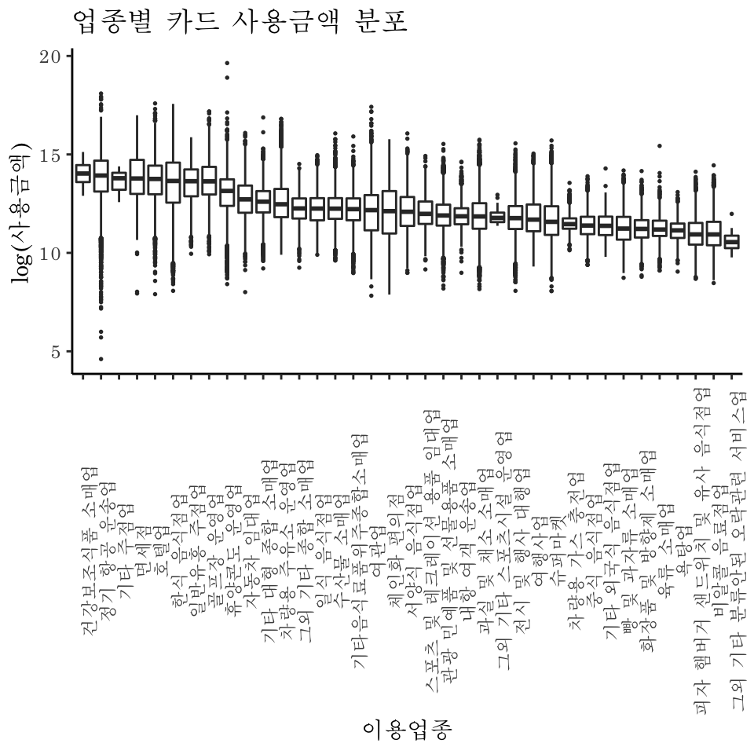

```r
lvls <-
  jj[, median(AMT), by = STD_CLSS_NM] %>% arrange(desc(V1)) %>% .[, STD_CLSS_NM] %>%
  as.character
mutate(jj, STD_CLSS_NM = factor(STD_CLSS_NM, levels = lvls)) %>% ggplot +
  geom_boxplot(aes(STD_CLSS_NM, log(AMT)), outlier.size = .3) +
  xlab('이용업종') + ylab('log(사용금액)') + theme_classic(base_family = f.fam) +
  theme(axis.text.x = element_text(angle = 90)) + ggtitle('업종별 카드 사용금액 분포')
```

분석주제 2.2. 이용금액 vs. 성별 박스플랏

성별별 카드 이용금액의 분포에는 큰 차이가 없었다. 다만 남성이 평균적으로 여성보다 더 소비한 것을 알 수 있다.

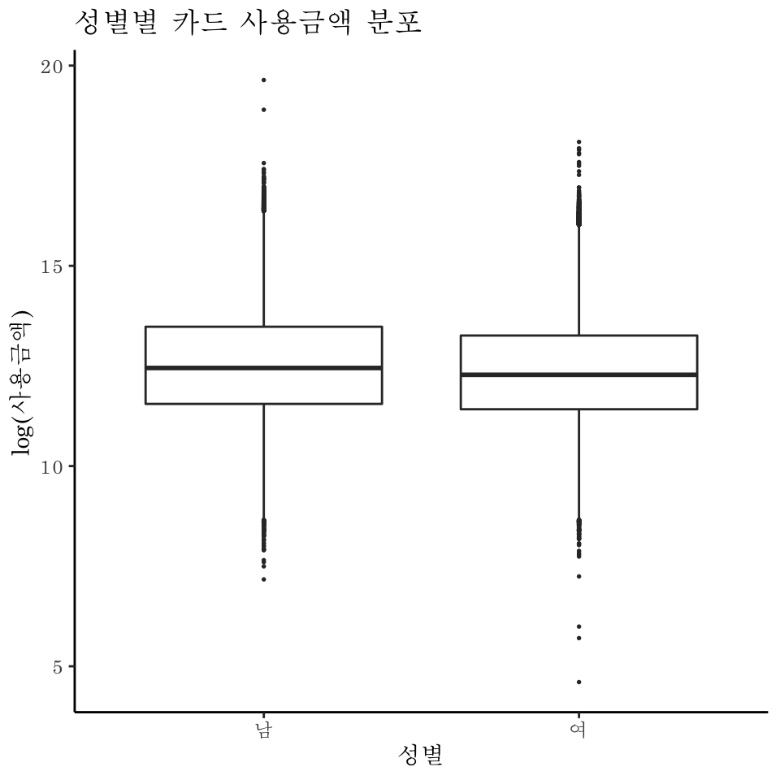

```r
lvls <-
  jj[, median(AMT), by = SEX_CTGO_CD] %>% arrange(desc(V1)) %>% .[, SEX_CTGO_CD] %>%
  as.character
mutate(jj, SEX_CTGO_CD = factor(SEX_CTGO_CD, levels = lvls)) %>% ggplot +
  geom_boxplot(aes(SEX_CTGO_CD, log(AMT)), outlier.size = .3) +
  xlab('성별') + ylab('log(사용금액)') + theme_classic(base_family = f.fam) +
  ggtitle('성별별 카드 사용금액 분포')
```

분석주제 2.3. 이용금액 vs. 연령대별 박스플랏

연령별 이용금액은 크기순으로 볼 때 70대부터 10대 순인 것으로 나타났다. 특히 10대의 경우 다른 연령대에 비해 눈에 띄게 이용금액이 적은것을 알 수 있다.

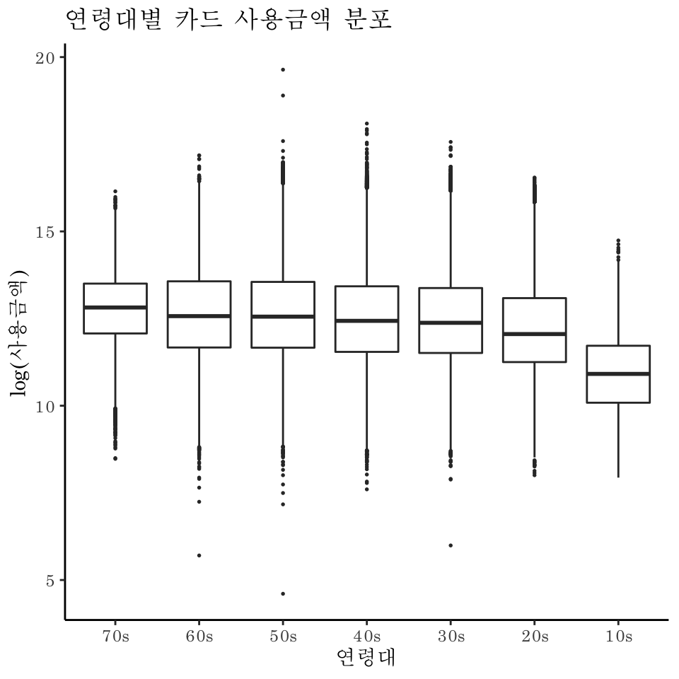

```r
lvls <-
  jj[, median(AMT), by = AGE] %>% arrange(desc(V1)) %>% .[, AGE] %>%
  as.character
mutate(jj, AGE = factor(AGE, levels = lvls)) %>% ggplot +
  geom_boxplot(aes(AGE, log(AMT)), outlier.size = .3) +
  xlab('연령대') + ylab('log(사용금액)') + theme_classic(base_family = f.fam) +
  ggtitle('연령대별 카드 사용금액 분포')
```

분석주제 2.4. 이용금액 vs. 가구생애주기별 박스플랏

가구생애주기별 이용금액 또한 5에서 1 크기순으로 나타났다.

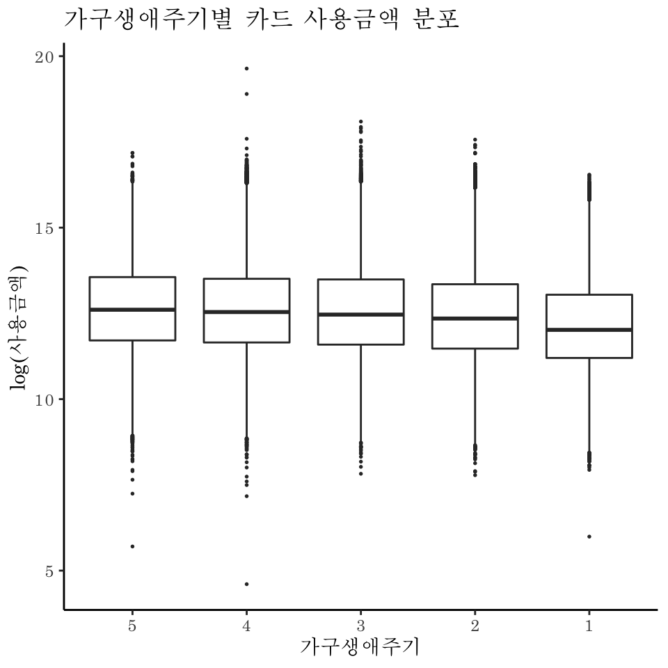

```r
lvls <-
  jj[, median(AMT), by = FLC] %>% arrange(desc(V1)) %>% .[, FLC] %>%
  as.character
mutate(jj, FLC = factor(FLC, levels = lvls)) %>% ggplot +
  geom_boxplot(aes(FLC, log(AMT)), outlier.size = .3) +
  xlab('가구생애주기') + ylab('log(사용금액)') + theme_classic(base_family = f.fam) +
  ggtitle('가구생애주기별 카드 사용금액 분포')
```

분석주제 2.5. 이용금액 vs. 년월별 박스플랏

연월별 이용금액의 분포는 큰 변동이 없는 것으로 나타났다.

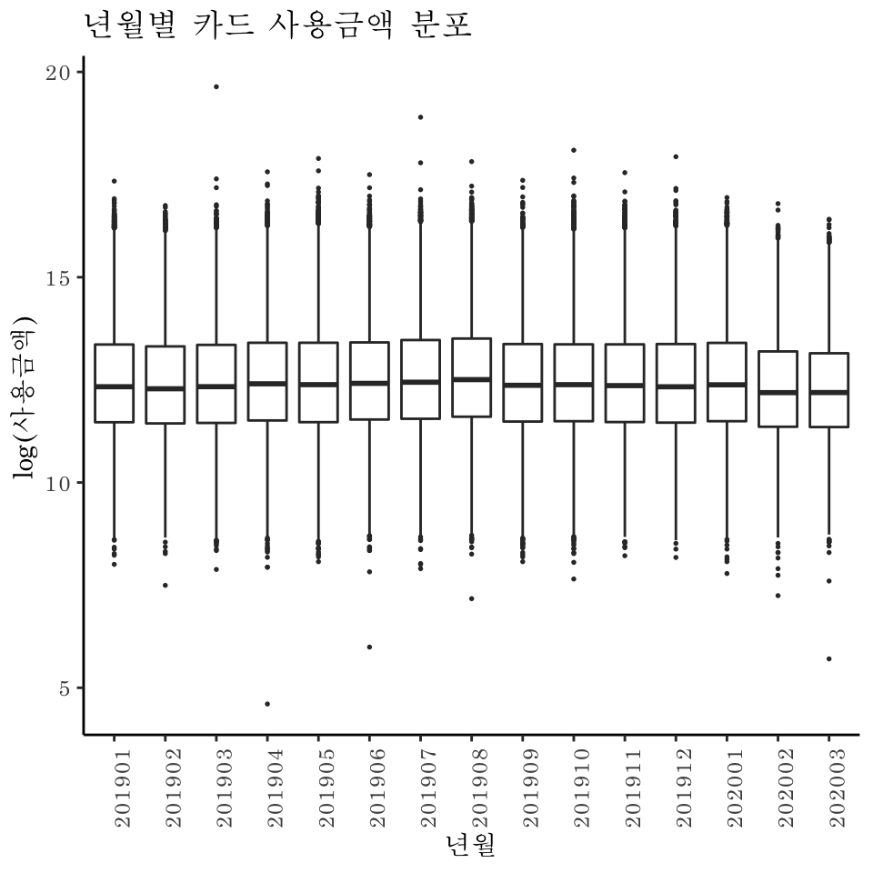

```r
mutate(jj, REG_YYMM = factor(REG_YYMM)) %>% ggplot +
  geom_boxplot(aes(REG_YYMM, log(AMT)), outlier.size = .3) +
  xlab('년월') + ylab('log(사용금액)') + theme_classic(base_family = f.fam) +
  theme(axis.text.x = element_text(angle = 90)) + ggtitle('년월별 카드 사용금액 분포')
```

분석주제 2.6. 이용금액 vs. 고객 주소지별 박스플랏

고객 거주지 시별 이용금액의 분포는 큰 차이가 없는 것으로 나타났다. 다만 서울의 경우 그 분포가 타지역에 비해 산포가 더 큰것으로 나타났다.

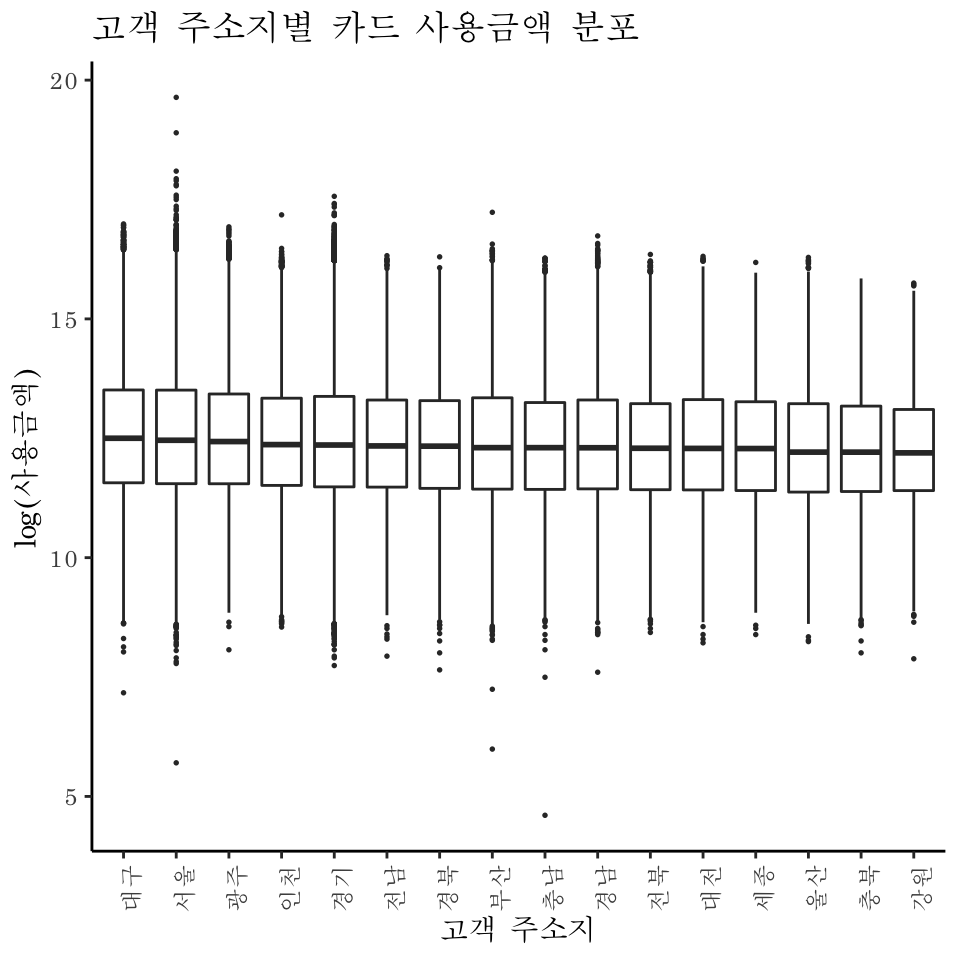

```r
lvls <-
  jj[, median(AMT), by = HOM_SIDO_NM] %>% arrange(desc(V1)) %>% .[, HOM_SIDO_NM] %>%
  as.character
mutate(jj, HOM_SIDO_NM = factor(HOM_SIDO_NM, levels = lvls)) %>% ggplot +
  geom_boxplot(aes(HOM_SIDO_NM, log(AMT)), outlier.size = .3) +
  xlab('고객 주소지') + ylab('log(사용금액)') + theme_classic(base_family = f.fam) +
  theme(axis.text.x = element_text(angle = 90)) + ggtitle('고객 주소지별 카드 사용금액 분포')
```

분석주제 3.1. 이용건수 ~ 연령대 + 성별

연령대별 이용건수 순으로 정렬하였다.  
30대가 가장 많이 카드를 이용했으며, 남성이 여성보다 눈에 띄게 더 많이 쓴 연령대는 40, 50, 60대였다. 반면 20대의 경우 여성의 이용건수가 더 두드러진다.

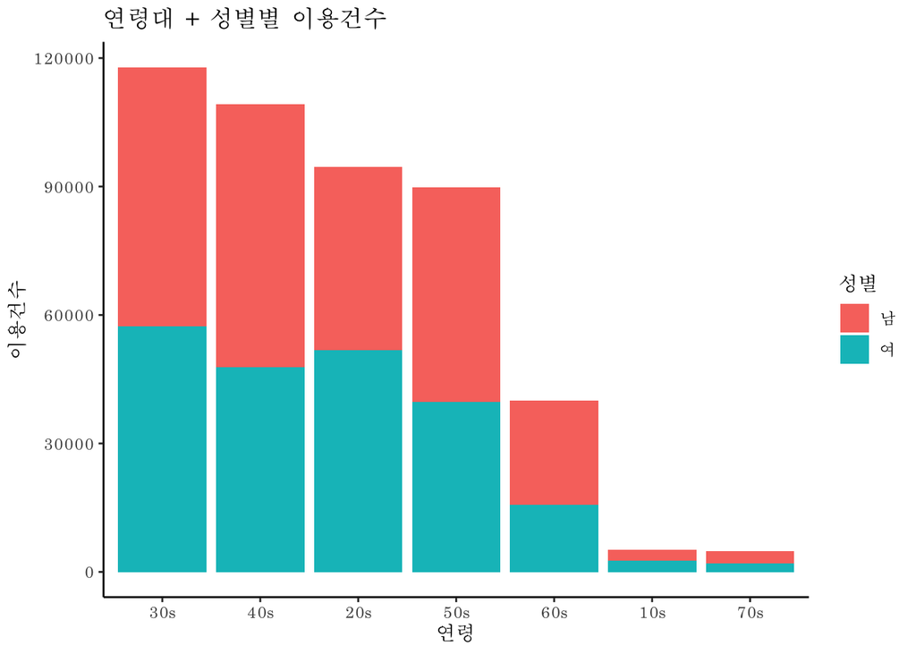

```r
lvls <-
  jj[, .N, by = AGE] %>% arrange(desc(N)) %>% .[, AGE] %>%
  as.character
mutate(jj, AGE = factor(AGE, levels = lvls)) %>% ggplot +
  geom_bar(aes(AGE, fill = SEX_CTGO_CD)) +
  xlab('연령') + ylab('이용건수') + theme_classic(base_family = f.fam) +
  ggtitle('연령대 + 성별별 이용건수') + labs(fill = '성별')
```

분석주제 3.2. 이용건수 ~ 연령대 + 이용업종

업종별 이용건수 순으로 정렬하였다.  
카드 이용건수는 한식 음식점업이 가장 많았다. 소비의 주축을 이룬것은 2,30대와 4,50대였는데, 젊은층의 소비가 두드러진 업종은 서양식 음식점업, 수산물 소매업, 과실 및 채소 소매업, 패스트푸드 음식점업 등이다. 60대 이상의 경우 한식 음식점업과 면세점 소비가 두드러졌다.

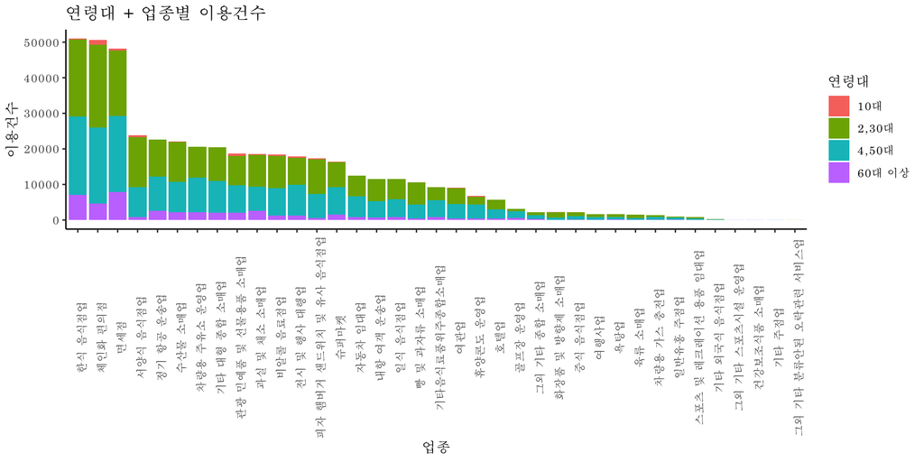

```r
lvls <-
  jj[, .N, by = STD_CLSS_NM] %>% arrange(desc(N)) %>% .[, STD_CLSS_NM] %>%
  as.character
mutate(jj, STD_CLSS_NM = factor(STD_CLSS_NM, levels = lvls)) %>%
  mutate(
    .,
    AGE.b := case_when(
      AGE == '10s' ~ "10대",
      AGE %in% c('20s', '30s') ~ "2,30대",
      AGE %in% c('40s', '50s') ~ "4,50대",
      T ~ "60대 이상"
    )
  ) %>% ggplot() +
  geom_bar(aes(STD_CLSS_NM, fill = AGE.b)) +
  xlab('업종') + ylab('이용건수') + theme_classic(base_family = f.fam) +
  theme(axis.text.x = element_text(angle = 90)) +
  ggtitle('연령대 + 업종별 이용건수') + labs(fill = '연령대')
```

분석주제 3.3. 이용건수 ~ 성별 + 이용업종

업종별 이용건수 순으로 정렬하였다.  
대체로 남녀 모두 고루 소비하는 업종들이 대부분이다. 다만 남성의 두드러진 소비가 있었던 업종은 주유소 운영업이었다.

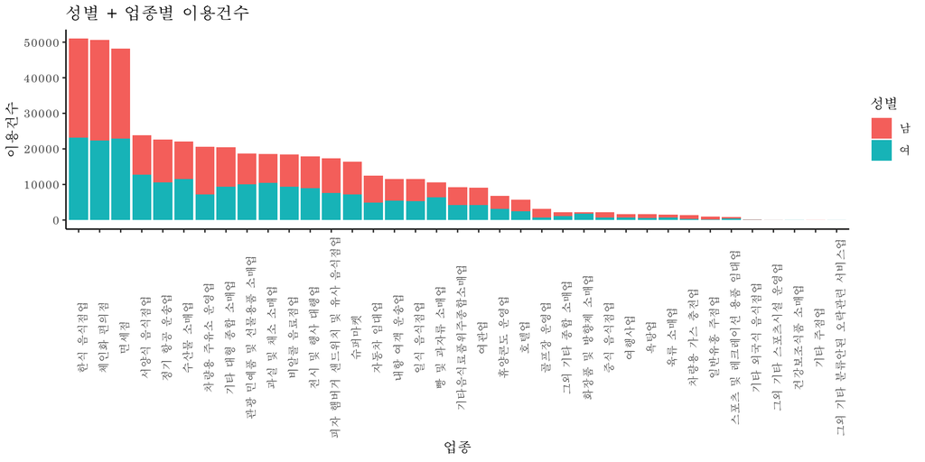

```r
lvls <-
  jj[, .N, by = STD_CLSS_NM] %>% arrange(desc(N)) %>% .[, STD_CLSS_NM] %>%
  as.character
mutate(jj, STD_CLSS_NM = factor(STD_CLSS_NM, levels = lvls)) %>% ggplot +
  geom_bar(aes(STD_CLSS_NM, fill = SEX_CTGO_CD)) +
  xlab('업종') + ylab('이용건수') + theme_classic(base_family = f.fam) +
  theme(axis.text.x = element_text(angle = 90)) +
  ggtitle('성별 + 업종별 이용건수') + labs(fill = '성별')
```

분석주제 3.4. 이용금액 ~ 성별 + 이용업종

업종별 이용금액 중위수 순으로 정렬하였다.  
건강보조식품 소매업, 일반유흥 주점업, 골프장 운영업, 자동차 임대업의 경우 남성의 소비가 더 많았다. 특히 기타 주점업은 소비금액 3위인데, 남성만이 이용하였다.

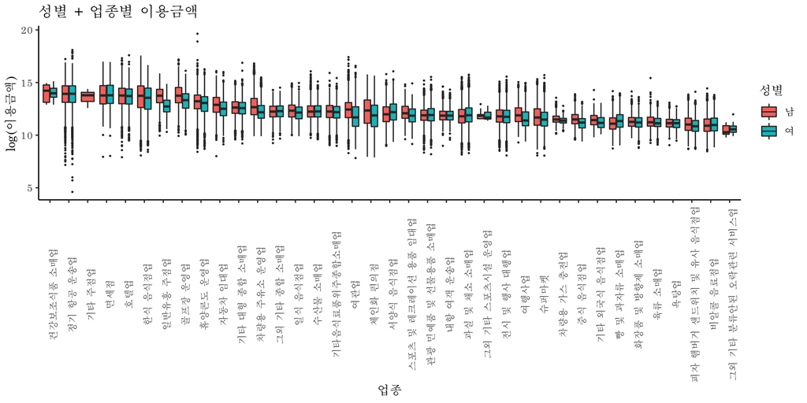

```r
lvls <-
  jj[, median(AMT), by = STD_CLSS_NM] %>% arrange(desc(V1)) %>% .[, STD_CLSS_NM] %>%
  as.character
mutate(jj, STD_CLSS_NM = factor(STD_CLSS_NM, levels = lvls)) %>% ggplot +
  geom_boxplot(aes(STD_CLSS_NM, log(AMT), fill = SEX_CTGO_CD),
               outlier.size = .3) +
  xlab('업종') + ylab('log(이용금액)') + theme_classic(base_family = f.fam) +
  theme(axis.text.x = element_text(angle = 90)) +
  ggtitle('성별 + 업종별 이용금액') + labs(fill = '성별')
```

분석주제 3.5. 이용금액 ~ 성별 + 연령대

연령대별 이용금액 중위수 순으로 정렬하였다.  
10대는 여성의 소비가 더 두드러졌으나, 다른 연령대에선 대체적으로 남성의 소비가 더 큰 경향이 있다.

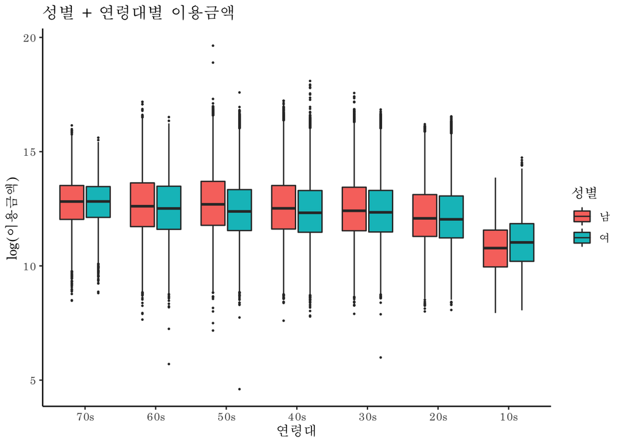

```r
lvls <-
  jj[, median(AMT), by = AGE] %>% arrange(desc(V1)) %>% .[, AGE] %>%
  as.character
mutate(jj, AGE = factor(AGE, levels = lvls)) %>% ggplot +
  geom_boxplot(aes(AGE, log(AMT), fill = SEX_CTGO_CD),
               outlier.size = .3) +
  xlab('연령대') + ylab('log(이용금액)') + theme_classic(base_family = f.fam) +
  ggtitle('성별 + 연령대별 이용금액') + labs(fill = '성별')
```